# SI 618: Data Manipulation and Analysis

## 04 - Visualization & Univariate Statistics

### Dr. Chris Teplovs, School of Information, University of Michigan

This work is licensed under a [Creative Commons Attribution-NonCommercial-ShareAlike 4.0 International License](http://creativecommons.org/licenses/by-nc-sa/4.0/).

Version 2023.09.20.1.CT

## Overview of today

- Announcements
- Comments/Questions/Concerns
- Review last week: Aggregation & Grouping
- Today: Univariate Statistics & Visualization

```python
import pandas as pd
import numpy as np
```

## A quick note about Markdown cells

We have encouraged you to use Markdown cells to add text to your notebooks. Please see https://jupyter-notebook.readthedocs.io/en/stable/examples/Notebook/Working%20With%20Markdown%20Cells.html for a more complete explanation of the use of Markdown in Jupyter. You can also examine any of the existing Markdown blocks by clicking on them.

### IMPORTANT: Replace `?` in the following code with your uniqname.

```python
MY_UNIQNAME = 'mattcalc'
```

## Aggregation and Grouping (review)

### Group By

```python
from io import StringIO

TESTDATA=StringIO("""State,Retailer,Fruit,Sales
MI,Walmart,Apple,100
MI,Wholefoods,Apple,150
MI,Kroger,Orange,180
CA,Walmart,Apple,220
CA,Wholefoods,Apple,180
CA,Safeway,Apple,220
CA,Safeway,Orange,110
NY,Walmart,Apple,90
NY,Walmart,Orange,80
NY,Wholefoods,Orange,120
""")

fruit = pd.read_csv(TESTDATA, index_col=None)
```

```python
fruit.head()
```

|  | State | Retailer | Fruit | Sales |
| --- | --- | --- | --- | --- |
| 0 | MI | Walmart | Apple | 100 |
| 1 | MI | Wholefoods | Apple | 150 |
| 2 | MI | Kroger | Orange | 180 |
| 3 | CA | Walmart | Apple | 220 |
| 4 | CA | Wholefoods | Apple | 180 |

#### (a) What is the total sales for each state?

This requires us to group by state, and aggregate sales by taking the sum.

The easiest way of doing this if to use `groupby`

If you execute groupby on the dataframe what you'll get back is an object called DataFrameGroupBy

```python
fruit.groupby('State')
```

```
<pandas.core.groupby.generic.DataFrameGroupBy object at 0x000001D34A7F3ED0>
```

On its own it's a bit useless... it just keeps track of which rows should go into each "pile" (where pile here means a unique group for each state)

If we ask this object to describe itself, you can see what is inside notice that it threw away all the other columns because they were not numerical. Only "Sales" which is a number, was kept

```python
fruit.groupby('State').describe()
```

| State | Sales count | Sales mean | Sales std | Sales min | Sales 25% | Sales 50% | Sales 75% | Sales max |
| --- | --- | --- | --- | --- | --- | --- | --- | --- |
| CA | 4.0 | 182.500000 | 51.881275 | 110.0 | 162.5 | 200.0 | 220.0 | 220.0 |
| MI | 3.0 | 143.333333 | 40.414519 | 100.0 | 125.0 | 150.0 | 165.0 | 180.0 |
| NY | 3.0 | 96.666667 | 20.816660 | 80.0 | 85.0 | 90.0 | 105.0 | 120.0 |

```python
# What are the total sales for each state?
fruit.groupby('State')['Sales'].sum()  # instead of size()
```

```
State
CA    730
MI    430
NY    290
Name: Sales, dtype: int64
```

What just happend? A couple of things:

- `groupby()` got first executed on `df`, returning an `DataFrameGroupBy` object. This object itself is useless unless coupled with an aggregation function, such as `sum()`, `mean()`, `max()`, `apply()`.
- Then, `sum()` got executed on the `DataFrameGroupBy` object, generating the `DataFrame` object you see above. Notice how the table looks different than the original DataFrame `df`? Here are the differences:
  - The `State` column now becomes the index of the DataFrame. The string "State" is the name of the index. Notice how the index name is displayed on a lower level than column names.
  - Since we performed a `groupby` operation by `State`, so only the unique values of `State` are kept as index.
  - Among the other columns, Retailer, Fruit, and Sales, only Sales is kept in the result table. This is because the aggregation function `sum()` only knows how to aggregate numerical values. And only Sales is a numerical column. The other columns are hence dropped.

#### (b) What is the total sales for each state for each fruit?

This requires us to perform `groupby` on two columns. So, we provide a list of column names to the `groupby` function.

Don't forget that an aggregation function needs to follow the `groupby` function in order to generate results.

```python
# What is the total sales for each state for each fruit?
fruit.groupby(['State', 'Fruit'])['Sales'].sum()
```

```
State  Fruit
CA     Apple     620
       Orange    110
MI     Apple     250
       Orange    180
NY     Apple      90
       Orange    200
Name: Sales, dtype: int64
```

How is this DataFrame different from the previous one?

The biggest different is that this DataFrame has what is called a `MultiIndex` (or hierarchical index), as opposed to a simple index. In this table, the left two "columns" are not columns but actually part of the `MultiIndex`, and the `Sales` is the single real "column" in the DataFrame. (Running out of terminologies here...)

The hierarchical index can be organized in an alternative way if we swapped the order of State and Fruit.

```python
fruit.groupby(['Fruit', 'State'])['Sales'].sum()
```

```
Fruit   State
Apple   CA       620
        MI       250
        NY        90
Orange  CA       110
        MI       180
        NY       200
Name: Sales, dtype: int64
```

#### (c) Which state has the maximum total sales?

This question is not asking about the maximum value, but rather which state holds that maximum. There are multiple ways to do it. A principled way is to use `idxmax`.

```python
# Which state has the maximum total sales?
fruitSalesByState = fruit.groupby('State')['Sales'].sum()
print(fruitSalesByState)
max_state = fruitSalesByState.idxmax()
print("The state with the maximum sales is: ",max_state)
```

```
State
CA    730
MI    430
NY    290
Name: Sales, dtype: int64
The state with the maximum sales is:  CA
```

What if we wanted to get the sales value of CA again?

```python
fruitSalesByState[max_state]
```

```
730
```

#### (d) Which state has the maximum total sales for apples?

```python
# Which state has the maximum total sales for apples?
# give me apple sellers
apples = fruit[fruit.Fruit == 'Apple']
apples
```

|  | State | Retailer | Fruit | Sales |
| --- | --- | --- | --- | --- |
| 0 | MI | Walmart | Apple | 100 |
| 1 | MI | Wholefoods | Apple | 150 |
| 3 | CA | Walmart | Apple | 220 |
| 4 | CA | Wholefoods | Apple | 180 |
| 5 | CA | Safeway | Apple | 220 |
| 7 | NY | Walmart | Apple | 90 |

```python
# aggr. by state
applesByState = apples.groupby('State')['Sales'].sum()
applesByState
```

```
State
CA    620
MI    250
NY     90
Name: Sales, dtype: int64
```

## Visualization and Univariate Statistics

Think about plotting the relationship between X and Y for the following data:

[figure not shown]

([https://en.wikipedia.org/wiki/Anscombe's_quartet](https://en.wikipedia.org/wiki/Anscombe%27s_quartet))

A nice linear relationship, right?

[figure not shown]

([https://en.wikipedia.org/wiki/Anscombe's_quartet](https://en.wikipedia.org/wiki/Anscombe%27s_quartet))

# Anscombe's Quartet

[figure not shown]

([https://en.wikipedia.org/wiki/Anscombe's_quartet](https://en.wikipedia.org/wiki/Anscombe%27s_quartet))

## Matplotlib, the basis for visualization in python

Matplotlib home page: https://matplotlib.org/index.html

Gallery: https://matplotlib.org/gallery/index.html

Sample plots: https://matplotlib.org/tutorials/introductory/sample_plots.html

https://matplotlib.org/users/pyplot_tutorial.html

matplotlib.pyplot is a collection of command style functions that make matplotlib work like MATLAB. Each pyplot function makes some change to a figure: e.g., creates a figure, creates a plotting area in a figure, plots some lines in a plotting area, decorates the plot with labels, etc.

## matplotlib.pyplot

- collection of functions that make matplotlib work like MATLAB (is that helpful???)
- each function makes some change to a figure:
  - create a figure
  - create a plotting area in a figure
  - plots some lines in a plotting area
  - decorates the plot with labels, etc.
- states are preserved across function calls

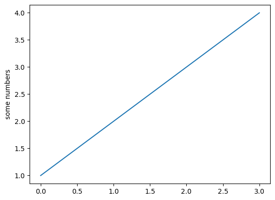

```python
import matplotlib.pyplot as plt
plt.plot([1, 2, 3, 4])
plt.ylabel('some numbers')
plt.show()
```

### Q1: Where did the numbers on the x-axis come from?

The y-values came from the [1,2,3,4] series

The x-values come form the dafault which start at 0 then increment by 1 for each y-value

To specify x- and y-values:

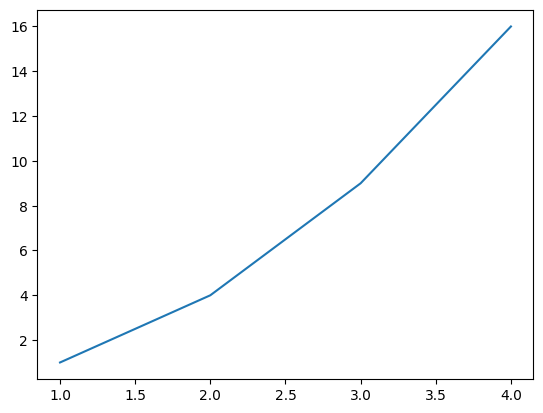

```python
plt.plot([1, 2, 3, 4], [1, 4, 9, 16])
```

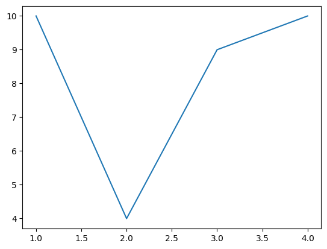

```python
import matplotlib.pyplot as plt
plt.plot([1,2,3,4], [10,4,9,10])
plt.show()
```

Note default shape is "b-", which means a blue line

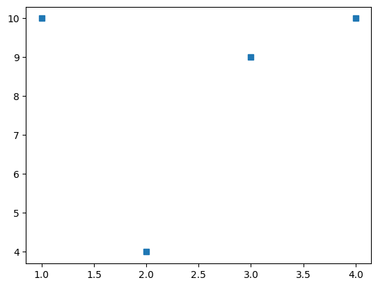

```python
import matplotlib.pyplot as plt
plt.plot([1,2,3,4], [10,4,9,10], 's')
plt.show()
```

We can explicitly set the bounds for the axes:

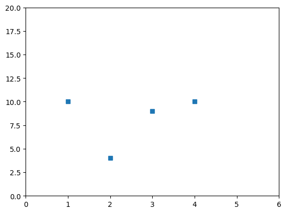

```python
import matplotlib.pyplot as plt
plt.plot([1,2,3,4], [10,4,9,10], 's')
plt.axis([0, 6, 0, 20])
plt.show()
```

Let's generate some data to play with:

```python
import numpy as np
import matplotlib.pyplot as plt

# evenly sampled time at 200ms intervals
t = np.arange(0., 5.2, 0.2)
t
```

```
array([0. , 0.2, 0.4, 0.6, 0.8, 1. , 1.2, 1.4, 1.6, 1.8, 2. , 2.2, 2.4,
       2.6, 2.8, 3. , 3.2, 3.4, 3.6, 3.8, 4. , 4.2, 4.4, 4.6, 4.8, 5. ])
```

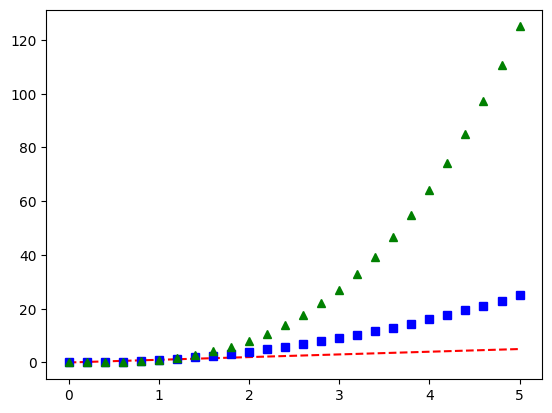

```python
# red dashes, blue squares and green triangles
plt.plot(t, t, 'r--', t, t**2, 'bs', t, t**3, 'g^')
plt.show()
```

```python
# listing of all marker types
markers = {'.': 'point', ',': 'pixel', 'o': 'circle',
    'v': 'triangle_down', '^': 'triangle_up', '<': 'triangle_left', '>': 'triangle_right',
    '1': 'tri_down', '2': 'tri_up', '3': 'tri_left', '4': 'tri_right', '8': 'octagon',
    's': 'square', 'p': 'pentagon', '*': 'star', 'h': 'hexagon1', 'H': 'hexagon2', '+': 'plus',
    'x': 'x', 'D': 'diamond', 'd': 'thin_diamond', '|': 'vline', '_': 'hline',
    'P': 'plus_filled', 'X': 'x_filled', 0:
    'tickleft', 1: 'tickright', 2: 'tickup', 3: 'tickdown',
    4: 'caretleft', 5: 'caretright', 6: 'caretup', 7: 'caretdown',
    8: 'caretleftbase', 9: 'caretrightbase', 10: 'caretupbase', 11: 'caretdownbase',
    'None': 'nothing', None: 'nothing', ' ': 'nothing', '': 'nothing'}
```

https://matplotlib.org/3.0.3/api/markers_api.html#module-matplotlib.markers

https://matplotlib.org/api/_as_gen/matplotlib.lines.Line2D.html#matplotlib.lines.Line2D

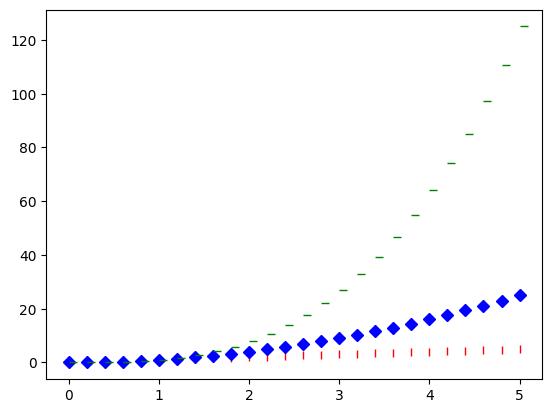

```python
plt.plot(t, t, marker='|', linestyle='', color='r')
plt.plot(t, t**2, marker='D', linestyle='', color='b')
plt.plot(t, t**3, marker=1, linestyle='', color='g')
plt.show()
```

### Q2: Try some other marker styles

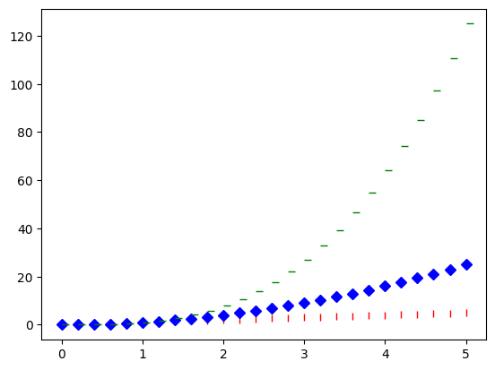

```python
# insert your code here
plt.plot(t, t, marker='|', linestyle='', color='r')
plt.plot(t, t**2, marker='D', linestyle='', color='b')
plt.plot(t, t**3, marker=1, linestyle='', color='g')
plt.show()
```

## Setting line properties

```python
x, y = [1, 2, 3, 4], [1, 4, 9, 16]
```

```python
x
```

```
[1, 2, 3, 4]
```

```python
y
```

```
[1, 4, 9, 16]
```

Keyword args:

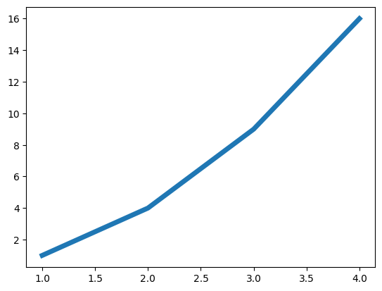

```python
plt.plot(x, y, linewidth=5.0)
```

setter methods:

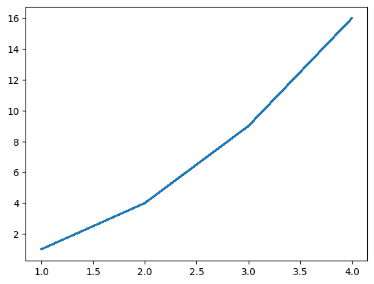

```python
# plt.plot() retruns not only a plot but also data baout he plot. using unpacking we can assign it to a variable
line, = plt.plot(x, y, '-')
line.set_antialiased(False)
```

`setp()`

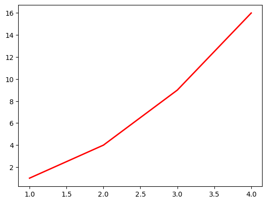

```python
line = plt.plot(x,y)
# use keyword args
plt.setp(line, color='r', linewidth=2.0)
# or MATLAB style string value pairs
plt.setp(line, 'color', 'r', 'linewidth', 2.0)
plt.show()
```

## Multiple plots

```python
def f(t):
    return np.exp(-t) * np.cos(2*np.pi*t)


t1 = np.arange(0.0, 5.1, 0.1)
t2 = np.arange(0.0, 5.02, 0.02)
```

```python
t1
```

```
array([0. , 0.1, 0.2, 0.3, 0.4, 0.5, 0.6, 0.7, 0.8, 0.9, 1. , 1.1, 1.2,
       1.3, 1.4, 1.5, 1.6, 1.7, 1.8, 1.9, 2. , 2.1, 2.2, 2.3, 2.4, 2.5,
       2.6, 2.7, 2.8, 2.9, 3. , 3.1, 3.2, 3.3, 3.4, 3.5, 3.6, 3.7, 3.8,
       3.9, 4. , 4.1, 4.2, 4.3, 4.4, 4.5, 4.6, 4.7, 4.8, 4.9, 5. ])
```

```python
t2
```

```
array([0.  , 0.02, 0.04, 0.06, 0.08, 0.1 , 0.12, 0.14, 0.16, 0.18, 0.2 ,
       0.22, 0.24, 0.26, 0.28, 0.3 , 0.32, 0.34, 0.36, 0.38, 0.4 , 0.42,
       0.44, 0.46, 0.48, 0.5 , 0.52, 0.54, 0.56, 0.58, 0.6 , 0.62, 0.64,
       0.66, 0.68, 0.7 , 0.72, 0.74, 0.76, 0.78, 0.8 , 0.82, 0.84, 0.86,
       0.88, 0.9 , 0.92, 0.94, 0.96, 0.98, 1.  , 1.02, 1.04, 1.06, 1.08,
       1.1 , 1.12, 1.14, 1.16, 1.18, 1.2 , 1.22, 1.24, 1.26, 1.28, 1.3 ,
       1.32, 1.34, 1.36, 1.38, 1.4 , 1.42, 1.44, 1.46, 1.48, 1.5 , 1.52,
       1.54, 1.56, 1.58, 1.6 , 1.62, 1.64, 1.66, 1.68, 1.7 , 1.72, 1.74,
       1.76, 1.78, 1.8 , 1.82, 1.84, 1.86, 1.88, 1.9 , 1.92, 1.94, 1.96,
       1.98, 2.  , 2.02, 2.04, 2.06, 2.08, 2.1 , 2.12, 2.14, 2.16, 2.18,
       2.2 , 2.22, 2.24, 2.26, 2.28, 2.3 , 2.32, 2.34, 2.36, 2.38, 2.4 ,
       2.42, 2.44, 2.46, 2.48, 2.5 , 2.52, 2.54, 2.56, 2.58, 2.6 , 2.62,
       2.64, 2.66, 2.68, 2.7 , 2.72, 2.74, 2.76, 2.78, 2.8 , 2.82, 2.84,
       2.86, 2.88, 2.9 , 2.92, 2.94, 2.96, 2.98, 3.  , 3.02, 3.04, 3.06,
       3.08, 3.1 , 3.12, 3.14, 3.16, 3.18, 3.2 , 3.22, 3.24, 3.26, 3.28,
       3.3 , 3.32, 3.34, 3.36, 3.38, 3.4 , 3.42, 3.44, 3.46, 3.48, 3.5 ,
       3.52, 3.54, 3.56, 3.58, 3.6 , 3.62, 3.64, 3.66, 3.68, 3.7 , 3.72,
       3.74, 3.76, 3.78, 3.8 , 3.82, 3.84, 3.86, 3.88, 3.9 , 3.92, 3.94,
       3.96, 3.98, 4.  , 4.02, 4.04, 4.06, 4.08, 4.1 , 4.12, 4.14, 4.16,
       4.18, 4.2 , 4.22, 4.24, 4.26, 4.28, 4.3 , 4.32, 4.34, 4.36, 4.38,
       4.4 , 4.42, 4.44, 4.46, 4.48, 4.5 , 4.52, 4.54, 4.56, 4.58, 4.6 ,
       4.62, 4.64, 4.66, 4.68, 4.7 , 4.72, 4.74, 4.76, 4.78, 4.8 , 4.82,
       4.84, 4.86, 4.88, 4.9 , 4.92, 4.94, 4.96, 4.98, 5.  ])
```

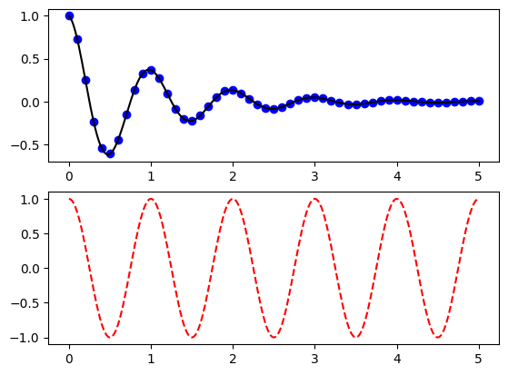

```python
plt.figure(1)
plt.subplot(211)
plt.plot(t1, f(t1), 'bo', t2, f(t2), 'k')

plt.subplot(212)
plt.plot(t2, np.cos(2*np.pi*t2), 'r--')
plt.show()
```

```python
# Simple data to display in various forms
x = np.linspace(0, 2 * np.pi, 400)
y = np.sin(x ** 2)
```

Just a figure and one subplot:

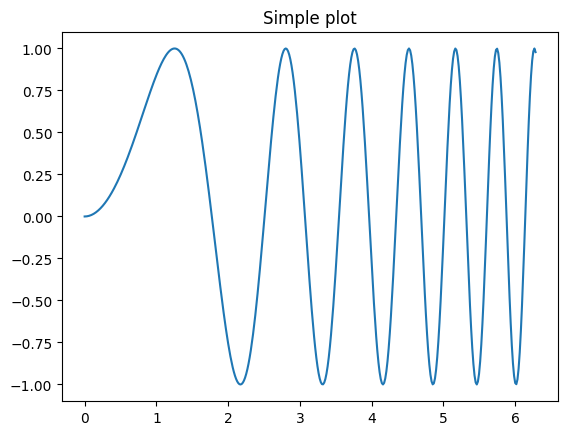

```python
f, ax = plt.subplots()
ax.plot(x, y)
ax.set_title('Simple plot')
plt.show()
```

Two subplots, the axes array is 1-d

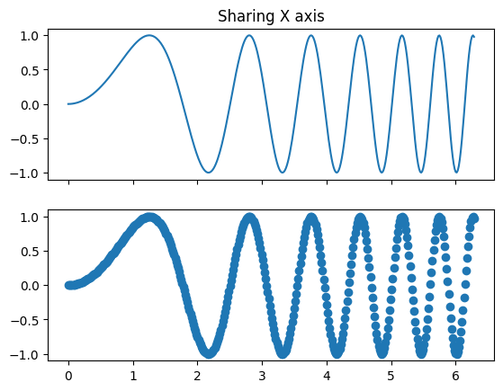

```python
f, axarr = plt.subplots(2, sharex=True)
axarr[0].plot(x, y)
axarr[0].set_title('Sharing X axis')
axarr[1].scatter(x, y)
plt.show()
```

Two subplots, unpack the axes array immediately

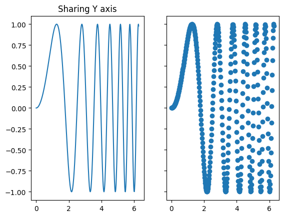

```python
f, (ax1, ax2) = plt.subplots(1, 2, sharey=True)
ax1.plot(x, y)
ax1.set_title('Sharing Y axis')
ax2.scatter(x, y)
```

Three subplots sharing both x/y axes

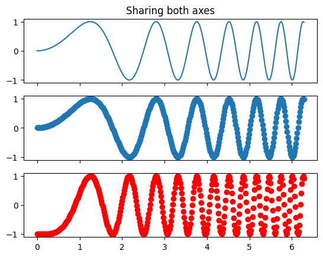

```python
f, (ax1, ax2, ax3) = plt.subplots(3, sharex=True, sharey=True)
ax1.plot(x, y)
ax1.set_title('Sharing both axes')
ax2.scatter(x, y)
ax3.scatter(x, 2 * y ** 2 - 1, color='r')
plt.show()
```

Fine-tune figure; make subplots close to each other and hide x ticks for all but bottom plot.

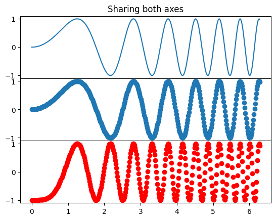

```python
f, (ax1, ax2, ax3) = plt.subplots(3, sharex=True, sharey=True)
ax1.plot(x, y)
ax1.set_title('Sharing both axes')
ax2.scatter(x, y)
ax3.scatter(x, 2 * y ** 2 - 1, color='r')

f.subplots_adjust(hspace=0)
plt.setp([a.get_xticklabels() for a in f.axes[:-1]], visible=False)
plt.show()
```

Row and column sharing:

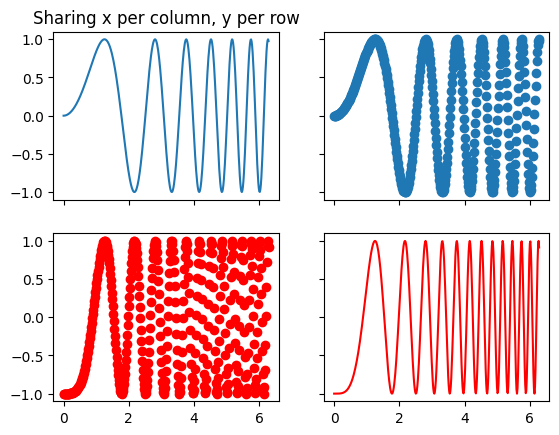

```python
f, ((ax1, ax2), (ax3, ax4)) = plt.subplots(2, 2, sharex='col', sharey='row')
ax1.plot(x, y)
ax1.set_title('Sharing x per column, y per row')
ax2.scatter(x, y)
ax3.scatter(x, 2 * y ** 2 - 1, color='r')
ax4.plot(x, 2 * y ** 2 - 1, color='r')
plt.show()
```

## Adding Text

```python
# Fixing random state for reproducibility
np.random.seed(618)

mu, sigma = 100, 15
x = mu + sigma * np.random.randn(10000)
```

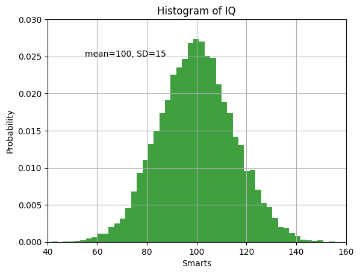

```python
# the histogram of the data
n, bins, patches = plt.hist(x, 50, density=True, facecolor='g', alpha=0.75)

plt.xlabel('Smarts')
plt.ylabel('Probability')
plt.title('Histogram of IQ')
plt.text(55, .025, 'mean=100, SD=15')
plt.axis([40, 160, 0, 0.03])
plt.grid(True)
plt.show()
```

See also [text properties and layout](https://matplotlib.org/users/text_props.html#text-properties).

## Annotating Text

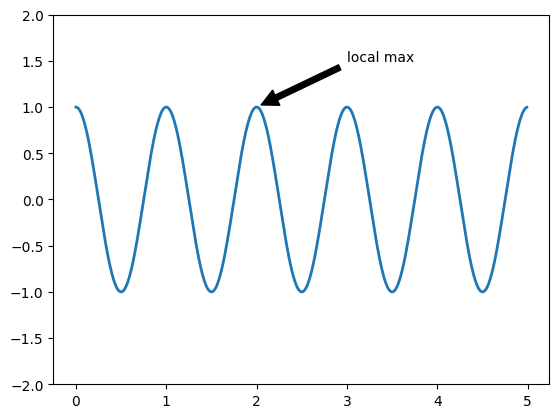

```python
ax = plt.subplot(111)

t = np.arange(0.0, 5.0, 0.01)
s = np.cos(2*np.pi*t)
line, = plt.plot(t, s, lw=2)

plt.annotate('local max',
             xy=(2, 1),
             xytext=(3, 1.5),
             arrowprops=dict(facecolor='black', shrink=0.05),
            )

plt.ylim(-2,2)
plt.show()
```

### Q3: Using the McDonald's menu dataset, plot any 2 continuous variables as a scatterplot and annotate an interesting feature (e.g. local max, outlier, etc.).

```python
menu = pd.read_csv('https://github.com/umsi-data-science/data/raw/main/menu.csv')
```

```python
menu.head()
```

|  | Category | Item | Serving Size | Calories | Calories from Fat | Total Fat | Total Fat (% Daily Value) | Saturated Fat | Saturated Fat (% Daily Value) | Trans Fat | ... | Carbohydrates | Carbohydrates (% Daily Value) | Dietary Fiber | Dietary Fiber (% Daily Value) | Sugars | Protein | Vitamin A (% Daily Value) | Vitamin C (% Daily Value) | Calcium (% Daily Value) | Iron (% Daily Value) |
| --- | --- | --- | --- | --- | --- | --- | --- | --- | --- | --- | --- | --- | --- | --- | --- | --- | --- | --- | --- | --- | --- |
| 0 | Breakfast | Egg McMuffin | 4.8 oz (136 g) | 300 | 120 | 13.0 | 20 | 5.0 | 25 | 0.0 | ... | 31 | 10 | 4 | 17 | 3 | 17 | 10 | 0 | 25 | 15 |
| 1 | Breakfast | Egg White Delight | 4.8 oz (135 g) | 250 | 70 | 8.0 | 12 | 3.0 | 15 | 0.0 | ... | 30 | 10 | 4 | 17 | 3 | 18 | 6 | 0 | 25 | 8 |
| 2 | Breakfast | Sausage McMuffin | 3.9 oz (111 g) | 370 | 200 | 23.0 | 35 | 8.0 | 42 | 0.0 | ... | 29 | 10 | 4 | 17 | 2 | 14 | 8 | 0 | 25 | 10 |
| 3 | Breakfast | Sausage McMuffin with Egg | 5.7 oz (161 g) | 450 | 250 | 28.0 | 43 | 10.0 | 52 | 0.0 | ... | 30 | 10 | 4 | 17 | 2 | 21 | 15 | 0 | 30 | 15 |
| 4 | Breakfast | Sausage McMuffin with Egg Whites | 5.7 oz (161 g) | 400 | 210 | 23.0 | 35 | 8.0 | 42 | 0.0 | ... | 30 | 10 | 4 | 17 | 2 | 21 | 6 | 0 | 25 | 10 |

5 rows × 24 columns

```python
menu.columns
menu.sort_values('Sodium', ascending=False)
```

|  | Category | Item | Serving Size | Calories | Calories from Fat | Total Fat | Total Fat (% Daily Value) | Saturated Fat | Saturated Fat (% Daily Value) | Trans Fat | ... | Carbohydrates | Carbohydrates (% Daily Value) | Dietary Fiber | Dietary Fiber (% Daily Value) | Sugars | Protein | Vitamin A (% Daily Value) | Vitamin C (% Daily Value) | Calcium (% Daily Value) | Iron (% Daily Value) |
| --- | --- | --- | --- | --- | --- | --- | --- | --- | --- | --- | --- | --- | --- | --- | --- | --- | --- | --- | --- | --- | --- |
| 82 | Chicken & Fish | Chicken McNuggets (40 piece) | 22.8 oz (646 g) | 1880 | 1060 | 118.0 | 182 | 20.0 | 101 | 1.0 | ... | 118 | 39 | 6 | 24 | 1 | 87 | 0 | 15 | 8 | 25 |
| 34 | Breakfast | Big Breakfast with Hotcakes and Egg Whites (La... | 15.4 oz (437 g) | 1050 | 450 | 50.0 | 77 | 16.0 | 81 | 0.0 | ... | 115 | 38 | 7 | 28 | 18 | 35 | 4 | 2 | 25 | 30 |
| 32 | Breakfast | Big Breakfast with Hotcakes (Large Biscuit) | 15.3 oz (434 g) | 1150 | 540 | 60.0 | 93 | 20.0 | 100 | 0.0 | ... | 116 | 39 | 7 | 28 | 17 | 36 | 15 | 2 | 30 | 40 |
| 33 | Breakfast | Big Breakfast with Hotcakes and Egg Whites (Re... | 14.9 oz (423 g) | 990 | 410 | 46.0 | 70 | 16.0 | 78 | 0.0 | ... | 110 | 37 | 6 | 23 | 17 | 35 | 0 | 2 | 25 | 30 |
| 31 | Breakfast | Big Breakfast with Hotcakes (Regular Biscuit) | 14.8 oz (420 g) | 1090 | 510 | 56.0 | 87 | 19.0 | 96 | 0.0 | ... | 111 | 37 | 6 | 23 | 17 | 36 | 15 | 2 | 25 | 40 |
| ... | ... | ... | ... | ... | ... | ... | ... | ... | ... | ... | ... | ... | ... | ... | ... | ... | ... | ... | ... | ... | ... |
| 134 | Beverages | Minute Maid Orange Juice (Medium) | 16 fl oz cup | 190 | 0 | 0.0 | 0 | 0.0 | 0 | 0.0 | ... | 44 | 15 | 0 | 0 | 39 | 3 | 0 | 160 | 4 | 0 |
| 133 | Beverages | Minute Maid Orange Juice (Small) | 12 fl oz cup | 150 | 0 | 0.0 | 0 | 0.0 | 0 | 0.0 | ... | 34 | 11 | 0 | 0 | 30 | 2 | 0 | 130 | 2 | 0 |
| 147 | Coffee & Tea | Coffee (Large) | 16 fl oz cup | 0 | 0 | 0.0 | 0 | 0.0 | 0 | 0.0 | ... | 0 | 0 | 0 | 0 | 0 | 0 | 0 | 0 | 0 | 0 |
| 113 | Beverages | Coca-Cola Classic (Child) | 12 fl oz cup | 100 | 0 | 0.0 | 0 | 0.0 | 0 | 0.0 | ... | 28 | 9 | 0 | 0 | 28 | 0 | 0 | 0 | 0 | 0 |
| 110 | Beverages | Coca-Cola Classic (Small) | 16 fl oz cup | 140 | 0 | 0.0 | 0 | 0.0 | 0 | 0.0 | ... | 39 | 13 | 0 | 0 | 39 | 0 | 0 | 0 | 0 | 0 |

260 rows × 24 columns

[figure not shown]

```python
plt.scatter(menu['Protein'], menu['Sodium'])
plt.title('McDonalds Menu Protein vs Sodium')
plt.xlabel('Protein')
plt.ylabel('Sodium')
plt.annotate('40 Piece McNugget', xy= (86, 3500), xytext=(55, 3000), arrowprops=dict(facecolor='black', shrink=0.05))
```

## Using specific types of plots via pyplot

In addition to scatterplots, pyplot offers a number of other plot types. These can be accessed via convenience functions such as `scatter()`, `hist()`, `bar()`, `barh()`, and `pie()`, amongst others:

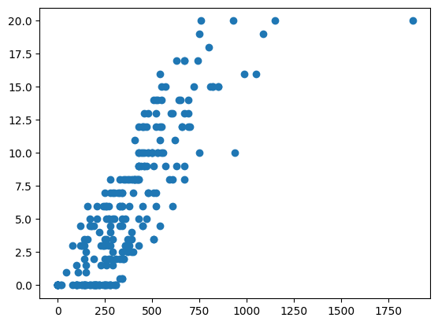

```python
plt.scatter(menu["Calories"], menu["Saturated Fat"])
plt.show()
```

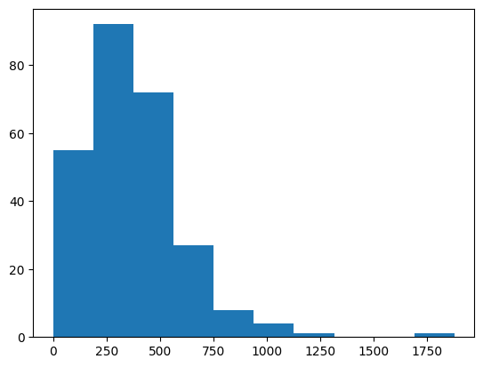

```python
plt.hist(menu['Calories'])
plt.show()
```

### Q4: Create a histogram of any one of the continuous variables from the McDonalds menu dataset.

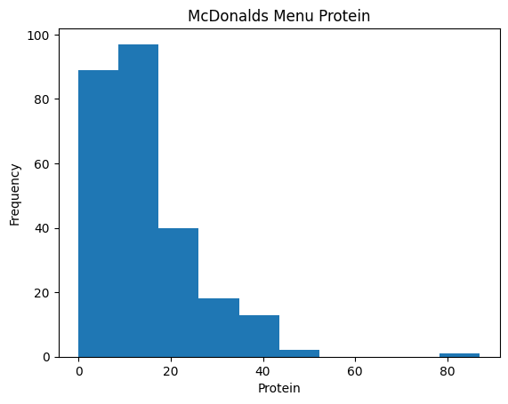

```python
plt.hist(menu['Protein'])
plt.xlabel('Protein')
plt.ylabel('Frequency')
plt.title('McDonalds Menu Protein')
plt.show()
```

## Pandas and matplotlib integration

Cumbersome? Yes. A better way? Use the matplotlib integration from pandas:

```
matplotlib.axes._axes.Axes
```

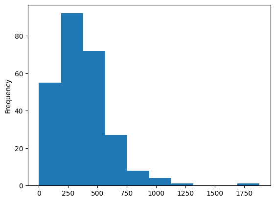

```python
f = menu['Calories'].plot(kind='hist')
type(f)
```

Here are the valid values for "kind":

kind : - 'line' : line plot (default) - 'bar' : vertical bar plot - 'barh' : horizontal bar plot - 'hist' : histogram - 'box' : boxplot - 'kde' : Kernel Density Estimation plot - 'density' : same as 'kde' - 'area' : area plot - 'pie' : pie plot

## Bar plots with groupby()

```python
categories = menu.groupby('Category').size()
```

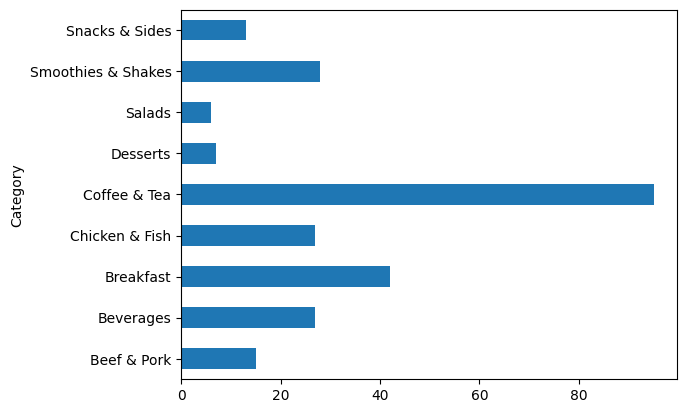

```python
categories.plot(kind='barh')
```

```python
categories_sorted = categories.sort_values(ascending=True)
```

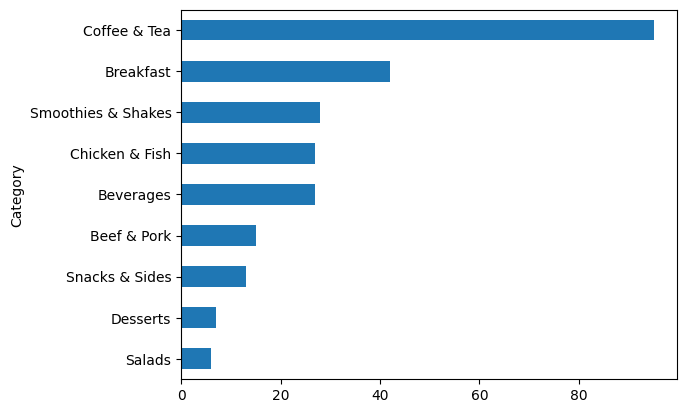

```python
categories_sorted.plot(kind='barh')
```

### Q5: Create a new column in the menu DataFrame called "Sugary" whose value is 1 if the values of "Sugars" is greater than 20, otherwise set it to 0.

```
Hint: use np.where(...) (look it up in the documentation)
```

```python
menu['Sugary'] = np.where(menu['Sugars'] > 20, 1, 0)
```

## Create a stacked bar plot by using a 2-level groupby() followed by an unstack():

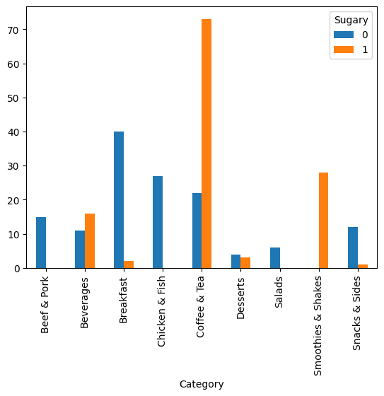

```python
menu.groupby(["Category", "Sugary"]).size().unstack().plot(kind="bar")
```

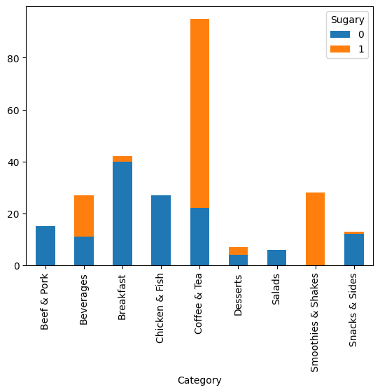

```python
menu.groupby(["Category", "Sugary"]).size().unstack().plot(kind="bar", stacked=True)
```

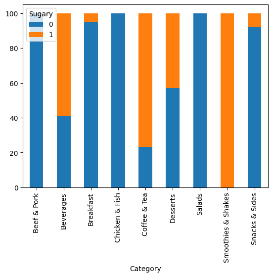

```python
menu.groupby(['Category', 'Sugary']).size().groupby(by='Category', group_keys=False).apply(
    lambda x: 100 * x / x.sum()
).unstack().plot(kind='bar', stacked=True)
```

### Q6: Repeat the above steps to generate three bar plots for any other continuous variable that you split into "high" and "low" values, just as with did with "Sugars" above.

```python
menu['Protein level'] = np.where(menu['Protein'] > 15, 'high', 'low')
```

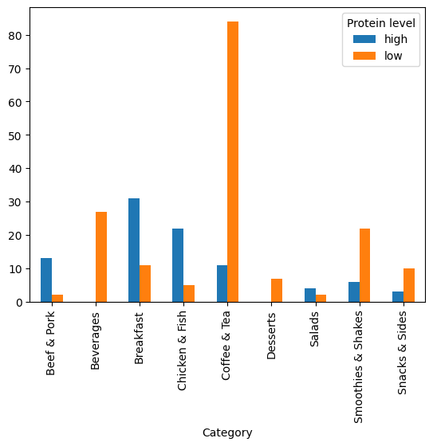

```python
menu.groupby(["Category", "Protein level"]).size().unstack().plot(kind="bar")
```

```python
menu.groupby(["Category", "Protein Level"]).size().unstack().plot(kind="bar", stacked=True)
```

[output not shown]

[output not shown]

```python
menu.groupby(['Category', 'Protein Level']).size().groupby(by='Category', group_keys=False).apply(
    lambda x: 100 * x / x.sum()
).unstack().plot(kind='bar', stacked=True)
```

[output not shown]

[output not shown]

### Pie Charts

There are many issues with pie charts, and the one below is a good example of what not to do, but everyone wants to know how to make them:

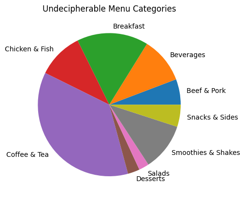

```python
# don't do this...
categories.plot(kind='pie', title='Undecipherable Menu Categories')
```

### Q7: What type of plot can *always* replace a pie chart?

You can always replace a pie chart with a bar chart